# Time Difference of Arrival based Target Pursuit: A Model Predictive Control Approach

**Presenter**: Anton Tolstonogov

**Institute**: Instituto Superior Técnico

**Course**: Dynamical System and Optimization

**Keywords**: TDoA localization, Target Pursuit, MPC, Autonomous Underwater Vehicle

# Introduction

**Motivation**:

- Monitoring and tracking marine life,
- Cheap navigation system for autonomous and remotely operated underwater vehicles.

**Challange**: The only information we have is the time difference between the arrival of the acoustic signal at the receivers installed on several trackers, emitted by a pinger installed on the target.

**Main Goal**: find solution for the **SLAP** problem (**S**imultaneous **L**ocalization **A**nd **P**ursuit) for two autonomous surface vehicles (**trackers**) to track underwater **targets** (AUVs, ROV, marine species with acoustic tags) using time-difference of arrival (TDoA) measurements.

**Aim of this work**: provide the first insight into the question of how to plan optimal motions for a set of two trackers to maximize the information available for the localization of a target based on TDoA-based measurements.

## Final Result

[video not shown]

# Problem Formulation

Consider two trackers charged with the task of following a moving target. In what follows, $\{\mathcal{I}\} = \{x_\mathcal{I}, y_\mathcal{I} \}$ denotes an inertial frame, $\{\mathcal{B}\}^{[i]} = \{ x^{[i]}_\mathcal{B}, y^{[i]}_\mathcal{B}\}$ denotes a body frame attached to the tracker $i \in \{1,2\}$, and $\{\mathcal{H}\} = \{x_\mathcal{H}, y_\mathcal{H} \}$ denotes a special frame attached to a center of a hyperbola naturally associated with the localization of a target using a TDoA solution, based on measurements obtained by acoustic receivers installed on the trackers.

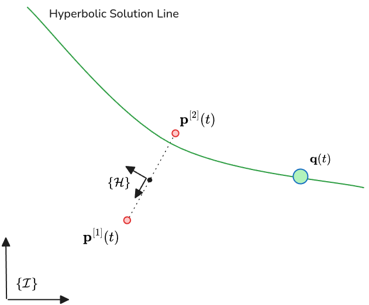

### Tracker Kinematic Model

The planar motion of tracker $i$ can be described by the simplified kinematic model: \begin{equation*} \begin{bmatrix} \dot{\mathbf{p}}^{[i]}\\ \dot{\psi}^{[i]} \end{bmatrix} = \begin{bmatrix} \dot{x}^{[i]} \\ \dot{y}^{[i]} \\ \dot{\psi}^{[i]} \end{bmatrix} = \begin{bmatrix} v^{[i]}\cos{\psi^{[i]}} \\ v^{[i]}\sin{\psi^{[i]}} \\ r^{[i]} \end{bmatrix} \end{equation*} where

- $\mathbf{p}^{[i]}=[x^{[i]}, y^{[i]}]^\intercal \in \mathbb{R}^2$ is the position of tracker $i$ in $\{\mathcal{I}\}$,
- $v^{[i]}$ is its total linear speed,
- $\psi^{[i]}$ is the heading angle,
- $r^{[i]}$ is the heading angle rate.

The trackers' model can now be rewritten in state-space form as follows \begin{equation*} \dot{\mathbf{x}}^{[i]} = \mathbf{g}(\mathbf{x}^{[i]}, \mathbf{u}^{[i]}) \end{equation*} where $\mathbf{x}^{[i]}=[x^{[i]}, y^{[i]}, \psi^{[i]}]^\intercal \in \mathbb{R}^3$ is the state vector and $\mathbf{u}^{[i]}=[v^{[i]},r^{[i]}]^\intercal \in \mathbb{R}^2$ is the input vector.

In the above, $\mathbf{g}(\mathbf{x}^{[i]}, \mathbf{u}^{[i]})$ is a nonlinear function given by $$ \mathbf{g}(\mathbf{x}^{[i]}, \mathbf{u}^{[i]}) = \begin{bmatrix} v^{[i]}\cos{\psi^{[i]}}\\ v^{[i]}\sin{\psi^{[i]}}\\ r^{[i]} \\ \end{bmatrix} $$

For the purpose of system design, will be discretized in time, yielding \begin{equation*} \mathbf{x}_{k+1}^{[i]} = \mathbf{g_d}(\mathbf{x}_{k}^{[i]}, \mathbf{u}_{k}^{[i]}) \end{equation*} where $k \in \mathbb{N}$ indexes discrete time instants and $\mathbf{g_d}(\cdot)$ is the nonlinear discrete function.

The Euler discretization method was used. In this case, the state $\mathbf{x}_{k+1}^{[i]}$ at the next step of the discretization is given by

\begin{equation*} \mathbf{x}_{k+1}^{[i]} = \begin{bmatrix} x^{[i]}_{k+1} \\ y^{[i]}_{k+1} \\ \psi^{[i]}_{k+1} \\ \end{bmatrix} = \begin{bmatrix} x^{[i]}_k \\ y^{[i]}_k \\ \psi^{[i]}_k \\ \end{bmatrix} + \Delta T \begin{bmatrix} v^{[i]}_k\cos{\psi^{[i]}_k}\\ v^{[i]}_k\sin{\psi^{[i]}_k}\\ r^{[i]}_k \\ \end{bmatrix} \end{equation*} where $\Delta T$ is the discretization period.

Because of physical limitations, the linear and rotational speeds of the trackers are bounded. For this reason, we will impose the state and input specified by $$ \mathbf{v}^{[i]} \in \mathcal{V} ^{[i]}, \mathbf{x}^{[i]} \in \mathcal{X} ^{[i]}, $$ where $\mathcal{V} ^{[i]} \subseteq \mathbb{R}^2$ and $\mathcal{X} ^{[i]} \subseteq \mathbb{R}^3$ are input and state constraint sets, respectively, for the trackers $i \in \{1,2\}$.

### Target Model

To ensure smooth and continuous motion, the target trajectory is modelled using a B-spline, which provides a flexible and efficient representation of curves.

Suppose that the target moves along a predefined trajectory $\mathbf{q}(u) = [q_x(u), q_y(u)]^\intercal \in \mathbb{R}^2$ described by a B-spline, where $u \in [0,1]$ is a parameter of the spline.

The B-spline curve $\mathbf{q}(u)$ of degree $p$ is expressed as a linear combination of basis functions in the form $$ \mathbf{q}(u) = \sum_{i=0}^{n-1}N_{i, p}(u)\mathbf{C}^{i}, $$ where $\mathbf{C}^{i} = [C_x^{i}, C_y^{i}]^\intercal \in \mathbb{R}^2$ are the control points of the B-spline ($i \in [1, \ldots, n_c]$), that is weights for the corresponding basis functions, and $N_{i,p}$ are the B-spline basis functions of degree $p$, defined in the knot vector $u = [u_0, \ldots, u_m]$, with $u_i \leq u_{i+1}$, where $m=n_c+p$.

### Target Model

To ensure smooth and continuous motion, the target trajectory is modelled using a B-spline, which provides a flexible and efficient representation of curves.

Suppose that the target moves along a predefined trajectory $\mathbf{q}(u) = [q_x(u), q_y(u)]^\intercal \in \mathbb{R}^2$ described by a B-spline, where $u \in [0,1]$ is a parameter of the spline.

The B-spline curve $\mathbf{q}(u)$ of degree $p$ is expressed as a linear combination of basis functions in the form $$ \mathbf{q}(u) = \sum_{i=0}^{n-1}N_{i, p}(u)\mathbf{C}^{i}, $$ where $\mathbf{C}^{i} = [C_x^{i}, C_y^{i}]^\intercal \in \mathbb{R}^2$ are the control points of the B-spline ($i \in [1, \ldots, n_c]$), that is weights for the corresponding basis functions, and $N_{i,p}$ are the B-spline basis functions of degree $p$, defined in the knot vector $u = [u_0, \ldots, u_m]$, with $u_i \leq u_{i+1}$, where $m=n_c+p$.

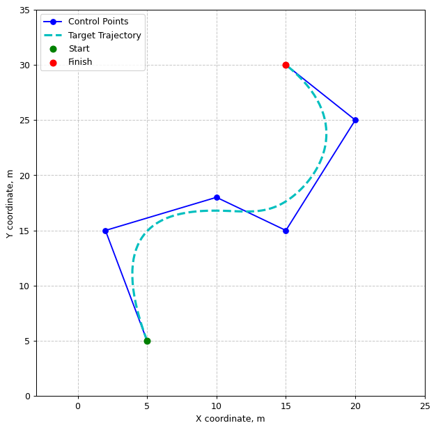

In this work, we require constant speed trajectory control; thus it is necessary to move the target along the B-spline curve at a constant speed during the simulation process, and the spline curve adjustment quantity $\Delta u$ needs to be updated at each interpolation cycle. Therefore, the discrete version of B-spline trajectory is adopted as follows: $$ \mathbf{q}(u_{k+1}) = \sum_{i=0}^{n-1}N_{i, p}(u_{k} + \Delta u_k)\mathbf{C}^{i}, $$ where $\Delta u$ is defined as $$ \Delta u_k = \frac{v_t \Delta T}{|\frac{\delta \mathbf{q}(u)}{\delta u}|_{u=u_k}}. $$ Here, $v_t$ is the constant velocity of the target and $\Delta T$ is the interpolation period.

## Objective

The main objective is to find smooth linear speed $v^{[i]}(t)$ and heading rate $r^{[i]}(t)$ references for the autopilots of both trackers to fulfil the following tasks:

- **Target localization**: Ensure that the measurements provide "sufficiently rich range information" to estimate the target states based on TDoA-based measurements.
- **Target pursuit**: Guarantee that the trackers are in the vicinity of the target, ensuring that the distance from any tracker to a target does not exceed $r^* \in (0, R]$, where $R$ is a design parameter.

# Preliminary Analysis

The aim of this part is to present the TDoA-based measurement model and to select an appropriate geometric trajectory pattern based on the chosen metrics in order to maximize the localization capability of the target.

**TDoA** (**T**ime **D**ifference **o**f **A**rrival) is a technique used to estimate the location of a target or source by measuring the time differences at which a signal arrives at multiple receivers.

## TDoA-based Measurement Model

The position of the target in the case of two receivers lies on the hyperbola given by:

\begin{equation*} \frac{(q_{x,k}^{\mathcal{H}})^2}{a^2} - \frac{(q_{y,k}^{\mathcal{H}})^2}{b^2} = 1, \end{equation*}

where the semi-axes of the hyperbola $a$ and $b$ are given by

\begin{align*} a^2 &= (\frac{1}{2}DD_{1,2T})^2 \\ b^2 &= (\frac{1}{2}||\mathbf{p}_k^{[1]} - \mathbf{p}_k^{[2]}||)^2 - a^2 \end{align*}

where:

- $\mathbf{q}_k^{\mathcal{H}} = [q_{x,k}^{\mathcal{H}}, q_{y,k}^{\mathcal{H}}]^\intercal$ is the possible position of the target at discrete time $k$ in the hyperbolic reference frame $\{\mathcal{H}\}$.
- $||\mathbf{p}_k^{[1]} - \mathbf{p}_k^{[2]}||$ is the distance between two trackers,
- $DD_k^{1,2T}$ is a time difference of signal arrival between two trackers at discrete time $k$.

The representation of the solution in the hyperbolic frame $\mathcal{H}$, $\mathbf{q}_k^{\mathcal{H}}$, and in the inertial frame $\mathcal{I}$, $\mathbf{q}_k^{\mathcal{I}}$, is connected via the transformation matrix $T_k$ according to

\begin{equation*} \begin{bmatrix} q_{x,k}^{\mathcal{H}} \\ q_{y,k}^{\mathcal{H}} \\ 1 \end{bmatrix} = T_k \begin{bmatrix} q_{x,k}^{\mathcal{I}} \\ q_{y,k}^{\mathcal{I}} \\ 1 \end{bmatrix} = \begin{bmatrix} \cos{\theta_k} & -\sin{\theta_k} & C_k^x \\ \sin{\theta_k} & \cos{\theta_k} & C_k^y \\ 0 & 0 & 1 \\ \end{bmatrix} \begin{bmatrix} q_{x,k}^{\mathcal{I}} \\ q_{y,k}^{\mathcal{I}} \\ 1 \end{bmatrix} \end{equation*}

where $C_k = [C_k^x, C_k^y]^\intercal$ is the center between the trackers (the focus of the hyperbola) at time $k$, expressed in $\mathcal{I}$, specifically,

\begin{equation*} \begin{bmatrix} C_k^x\\ C_k^y \end{bmatrix} = \begin{bmatrix} \frac{1}{2}(x^{[1]}_k + x^{[2]}_k)\\ \frac{1}{2}(y^{[1]}_k + y^{[2]}_k)\\ \end{bmatrix} \end{equation*}

where $\mathbf{p}^{[1]} = [x^{[1]}_k, y^{[1]}_k]$ and $\mathbf{p}^{[2]} = [x^{[2]}_k, y^{[2]}_k]$ are the positions of tracker 1 and tracker 2, respectively, at time $k$.

The rotation angle $\theta_k$ is given by \begin{equation*} \theta_k = \arctan{(y^{[1]}_k - y^{[2]}_k, x^{[1]}_k - x^{[2]}_k)}. \end{equation*}

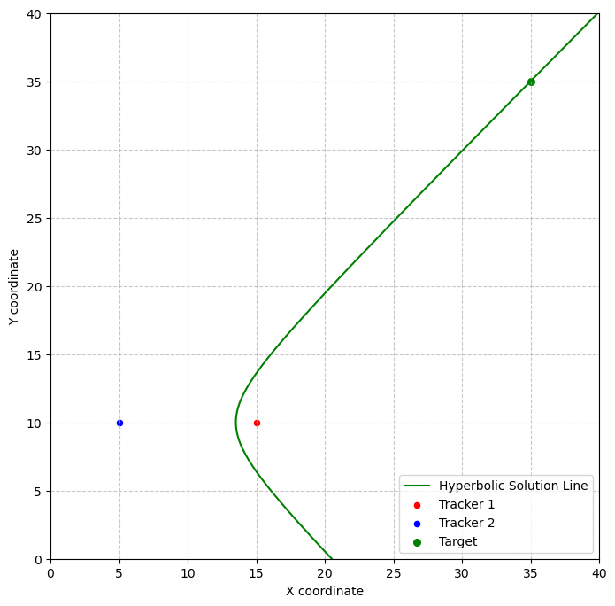

## Trajectory Pattern Comparison Metric

In this work, the time-cumulative histogram approach was used as a comparison metric for different movement patterns of the trackers. The main idea is to divide the 2D field into histogram bins of a given size and discretize the hyperbolic solution into a set of points. If the point of solution lies within a histogram bin, the counter for that bin is incremented. This process is then repeated for each discrete moment when the trackers move along the trajectory patterns.

## Trajectory patterns

Previous results in the literature on target localization using range-based or bearing-based strategies show that circular orbits around the target may, under certain conditions, yield effective and quantifiable results in terms of maximizing the information available for target tracking.

In all the scenarios described below, the trackers moved within the circular area bounded by a radius of $R=20$ m around the point $[0,0]$, the position of the tracker $\mathbf{p}^{[t]}$ is fixed: $\mathbf{p}^{[t]} = [50, 50]$ m. The simulation time and the time discrete period for these simulations are the same and equal to $200$ s and $1$ s respectively.

### Rotation Around the Tracker 1

In this pattern, tracker 1 is fixed and tracker 2 orbits around tracker 1 with radius $R$ and angular velocity $\omega$ as follows: \begin{align*} \mathbf{p}^{[1]}(t) &= [x_\text{fix}^{[1]}, y_\text{fix}^{[2]}] \\ \mathbf{p}^{[2]}(t) &= [x_\text{fix}^{[1]} + R\cos{wt}, y_\text{fix}^{[1]} + R\sin{wt}]^\intercal \end{align*}

[video not shown]

#### Static version

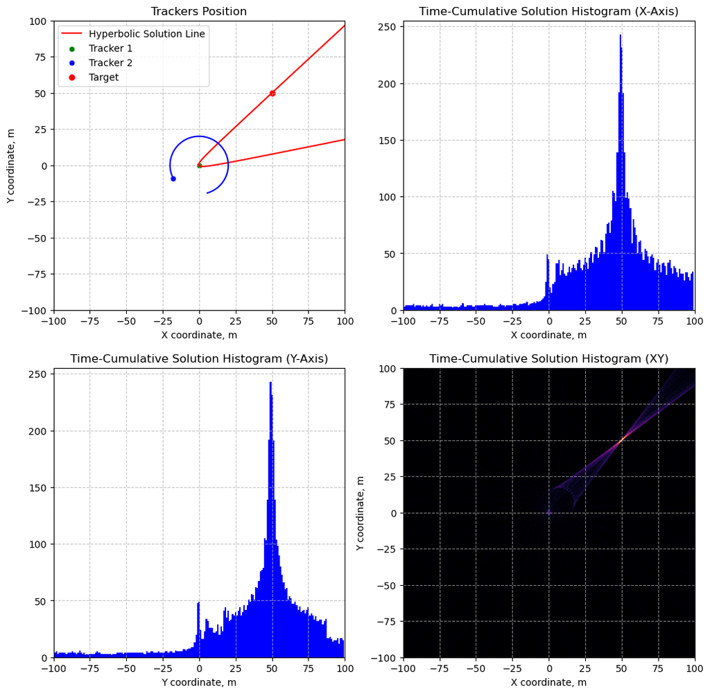

### Opposite Rotation

In this pattern, tracker 1 orbits around the center $\mathbf{c}=[c_x, c_y]^\intercal$ with radius $R_1$ and angular velocity $\omega_1>0$ and tracker 2 orbits around the same center with radius $R_2$ and angular velocity $\omega_2<0$ in opposite direction as follows: \begin{align*} \mathbf{p}^{[1]}(t) &= [c_x + R_1\cos{w_1t}, c_y + R_1\sin{w_1t}]^\intercal\\ \mathbf{p}^{[2]}(t) &= [c_x + R_2\cos{w_2t}, c_y + R_2\sin{w_2t}]^\intercal \end{align*} The radius $R_1, R_2$ and angular velocities $\omega_1$, $\omega_2$ are related as \begin{equation*} R_1 w_1 = R_2 w_2 \end{equation*} to make linear velocities of trackers the same.

[video not shown]

#### Static Version

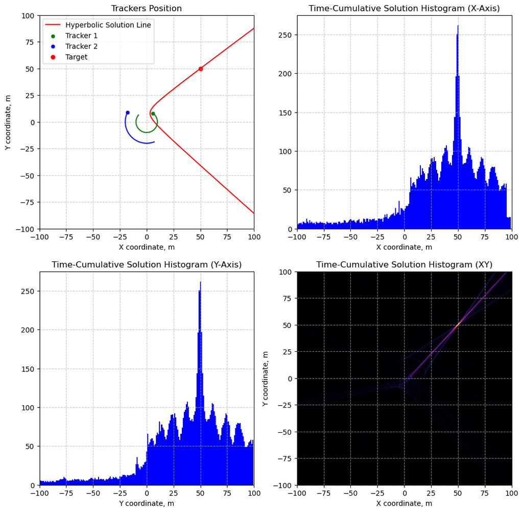

### Co-rotation with the $\pi$ Phase Shift

In this pattern, tracker 1 and tracker 2 orbit around the center $\mathbf{c}=[c_x, c_y]^\intercal$ with radius $R$ and angular velocity $\omega$, but the tracker 2 moves with the $\pi$ phase shift as follows: \begin{align*} \mathbf{p}^{[1]}(t) &= [c_x + R\cos{wt}, c_y + R\sin{wt}]^\intercal\\ \mathbf{p}^{[2]}(t) &= [c_x + R\cos{(wt + \pi)}, c_y + R\sin{(wt + \pi)}]^\intercal \end{align*}

[video not shown]

#### Static Version

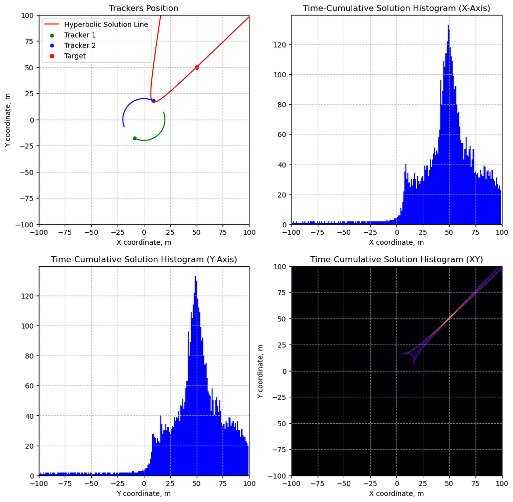

### Co-rotation with the $\pi/2$ Phase Shift

In this pattern, tracker 1 and tracker 2 orbit around the center $\mathbf{c}=[c_x, c_y]^\intercal$ with radius $R$ and angular velocity $\omega$, but the tracker 2 moves with the $\pi/2$ phase shift as follows: \begin{align*} \mathbf{p}^{[1]}(t) &= [c_x + R\cos{wt}, c_y + R\sin{wt}]^\intercal\\ \mathbf{p}^{[2]}(t) &= [c_x + R\cos{(wt + \pi/2)}, c_y + R\sin{(wt + \pi/2)}]^\intercal \end{align*}

[video not shown]

#### Static Version

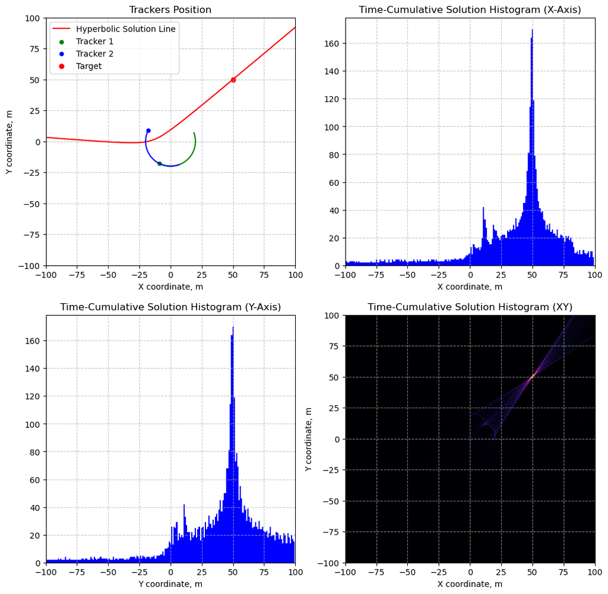

## Pattern Analysis Result

[output not shown]

## Pattern Analysis Result

# MPC framework for Target Pursuit

## Preliminary Analysis and Problem Decomposition

To address the target pursuit problem, we propose a scheme that involves the execution of three consecutive phases:

- **Phase 1.** Optimal motion planning for a so-called rotation center to follow the target based on target position and velocity information,
- **Phase 2.** Building desired circular trajectories for the trackers around the rotation center,
- **Phase 3.** optimal trackers' motion planning along the desired circular trajectories.

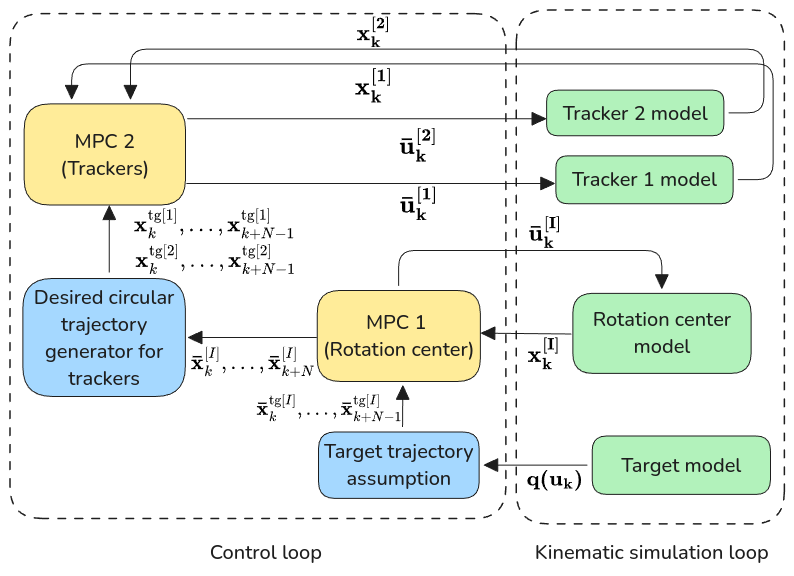

## Target Trajectory Linear assumption

Assume $\mathbf{x}^{[I]}_k$ be the state of the rotation point at discrete time $k$. The initial position of the rotation point at time $k=0$ is defined as the center between two trackers with a zero heading angle as follows:

\begin{equation*} \left.\mathbf{x}^{[I]}\right|_{k=0} = \begin{bmatrix} \frac{1}{2}(x^{[1]}_{k=0} + x^{[2]}_{k=0}) \\ \frac{1}{2}(y^{[1]}_{k=0} + y^{[2]}_{k=0}) \\ 0 \end{bmatrix} \end{equation*}

Assume that at each time $k$ the position $\mathbf{q}(u_k)=[q^x(u_k), q^y(u_k)]^\intercal$, heading $\psi^{[t]}_k$, and constant linear velocity $v_t$ of the target are known.

Given this information, we can make the **linear assumption** about the trajectory of the tracker within the prediction horizon of the MPC controller. \begin{align*} \bar{\mathbf{q}}_{n+1} &= \begin{bmatrix} q_x(u_{k+1}) \\ q_y(u_{k+1}) \end{bmatrix} = \Delta Tv_t \begin{bmatrix} \bar{q}_x(u_n)\cos{\psi^{[t]}_n} \\ \bar{q}_y(u_n)\sin{\psi^{[t]}_n} \end{bmatrix} \\ \bar{\mathbf{q}}_{n=0} &= \begin{bmatrix} q_x(u_k) \\ q_y(u_k) \end{bmatrix} \end{align*} for $n \in \{k,\ldots, k+N-1\}$.

## **Phase 1.** Optimal Motion Planning for the Rotation Center

The optimal control problem for the rotation center, denoted $\mathcal{OCP}1 (\mathbf{x}^{[I]}_k, \mathbf{u}^{[I]}_k, \mathbf{q}(u_k), \psi^{[t]}_k, v_t)$, is stated as follows \begin{equation*} \min_{\bar{\mathbf{u}}^{[I]}, \bar{\mathbf{x}}^{[I]}} J_\text{track}^{[D1]} + J_\text{velocity}^{[D1]}, \end{equation*} subject to \begin{align*} \bar{\mathbf{x}}_{n+1}^{[I]} &= \mathbf{g_d} (\bar{\mathbf{x}}_{n}^{[I]}, \bar{\mathbf{u}}_{n}^{[I]}) \\ \bar{\mathbf{x}}_{k}^{[I]} &= \mathbf{x}_k^{[I]} \\ \bar{\mathbf{x}}_{n}^{[I]} &\in \mathcal{X}^{[I]} \\ \bar{\mathbf{u}}_{n}^{[I]} &\in \mathcal{V}^{[I]} \end{align*} for $n \in \{k,\ldots, k+N-1\}$.

$J_\text{track}^{[D1]}$ is a cost function to pursue the target over its assumed trajectory, given by \begin{equation*} J_\text{track}^{[D1]} = \sum_{n=k}^{k+N-1} (\mathbf{p}^{[I]}_n - \bar{\mathbf{q}}_n)Q(\mathbf{p}^{[I]}_n - \bar{\mathbf{q}}_n)^\intercal, \end{equation*} where

- $Q$ is a diagonal non-negative weight matrix.

$J_\text{velocity}^{[D1]}$ is a const function to maintain the velocity of the rotation center along the prediction horizon, given by \begin{equation*} J_\text{velocity}^{[D1]} = \sum_{n=k}^{k+N-1} (\mathbf{u}^{[I]}_n - \mathbf{u}^{[t]})R(\mathbf{u}^{[I]}_n - \mathbf{u}^{[t]})^\intercal, \end{equation*} where

- $\mathbf{u}^{[t]} = [v_t, 0]^\intercal$ is the target's velocity vector,
- $R$ is a weight matrix.

## **Phase 2.** Building Desired Trajectories for Trackers

At each time instant $k$ we use predicted states $\bar{\mathbf{x}}^{[I]}$ received on the previous stage as the reference data to build up cirmumverence-like trajectories $[\mathbf{x}^{\text{tg}[1]}_{k}, \ldots \mathbf{x}^{\text{tg}[1]}_{k+N-1}]$, $[\mathbf{x}^{\text{tg}[2]}_{k}, \ldots \mathbf{x}^{\text{tg}[2]}_{k+N-1}]$ for the tracker 1 and the tracker 2 respectively as follows

\begin{equation*} \mathbf{x}^{\text{tg}[i]}_{n} = \begin{bmatrix} x^{\text{tg}[i]}_{n} \\ y^{\text{tg}[i]}_{n} \\ \psi^{\text{tg}[i]}_{n} \end{bmatrix} = \begin{bmatrix} \bar{x}^{[I]}_{n} + R\cos{wt_n + \varphi_i} \\ \bar{y}^{[I]}_{n} + R\sin{wt_n + \varphi_i} \\ \psi^{\text{tg}[i]}_{n} \end{bmatrix} \end{equation*} where $\psi^{\text{tg}[i]}_{n}$ is the angle of the tangent vector to the circumference at the point $[\bar{x}^{[I]}_{n} + R\cos{wt_n}, \bar{y}^{[I]}_{n} + R\sin{wt_n}]^\intercal$ for $n \in \{k,\ldots, k+N-1\}$ and for $i \in \{1,2\}$. The phase shift is denoted as $\varphi_i$ it equals

- $\varphi_1=0$ for the tracker 1,
- $\varphi_2 = \pi / 2$ for the tracker 2.

## Example of Desired Trajectories

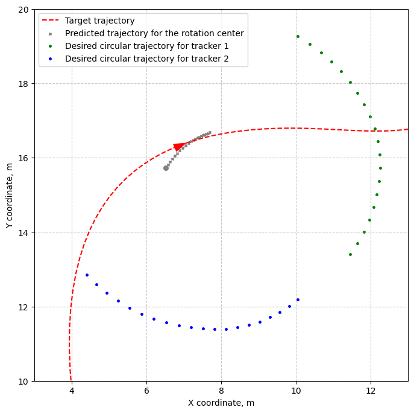

## **Phase 3.** Optimal Trackers' Motion Planning

The optimal control problem for the trackers, denoted $\mathcal{OCP}2 (\mathbf{x}^{[i]}_k, \mathbf{u}^{[i]}_k, \mathbf{x}^{\text{tg}[i]}_{k})$, is stated as follows \begin{equation*} \min_{\bar{\mathbf{u}}^{[i]}, \bar{\mathbf{x}}^{[i]}} J_\text{track}^{[D2]} + J_\text{velocity}^{[D2]} + J_\text{smooth}^{[D2]}, \end{equation*} subject to \begin{align*} \bar{\mathbf{x}}_{n+1}^{[i]} &= \mathbf{g_d} (\bar{\mathbf{x}}_{n}^{[i]}, \bar{\mathbf{u}}_{n}^{[I]}) \\ ||\bar{\mathbf{p}}_{n}^{[1]}& - \bar{\mathbf{p}}_{n}^{[2]}|| > R_a \\ \bar{\mathbf{x}}_{k}^{[i]} &= \mathbf{x}^{[i]} \\ \bar{\mathbf{x}}_{n}^{[i]} &\in \mathcal{X}^{[i]} \\ \bar{\mathbf{u}}_{n}^{[i]} &\in \mathcal{V}^{[i]} \end{align*} for $n \in \{k,\ldots, k+N-1\}$ and $i \in \{1,2\}$.

The definition of $\mathcal{OCP}2$ is similar to the definition of $\mathcal{OCP}1$ except for the second constraint.

This constraint ensures collision avoidance between the trackers, where $||\bar{\mathbf{p}}_{n}^{[1]} - \bar{\mathbf{p}}_{n}^{[2]}||$ is the distance between the trackers and $R_a$ is the collision avoidance minimal radius.

$J_\text{track}^{[D2]}$ is a cost function orbiting the rotation center along the desired trajectory, given by

\begin{equation*} J_\text{track}^{[D2]} = \sum_{i=1}^{2} \sum_{n=k}^{k+N-1} (\mathbf{x}^{[i]}_n - \mathbf{x}^{\text{tg}[i]}_n)Q(\mathbf{x}^{[i]}_n - \mathbf{x}^{\text{tg}[i]}_n)^\intercal, \end{equation*} where $Q$ is a diagonal non-negative weight matrix for states.

$J_\text{velocity}^{[D2]}$ is a const function to maintain the velocity of the trackers, given by \begin{equation*} J_\text{velocity}^{[D2]} = \sum_{i=1}^{2} \sum_{n=k}^{k+N-1} (\mathbf{u}^{[i]}_n - \mathbf{u}^{\text{tg}})R(\mathbf{u}^{[i]}_n - \mathbf{u}^{\text{tg}})^\intercal, \end{equation*} where $\mathbf{u}^{\text{tg}} = [R w, w]^\intercal$ is consists of the desired linear and angular vector of the tracker $i$ on the trajectory. Orbital angular velocity $w$ and the orbital radius $R$ are predefined parameters.

$J_\text{smooth}^{[D2]}$ is a cost function to penalize significant differences between neighboring control actions in the prediction horizon as follows: \begin{equation*} J_\text{smooth}^{[D2]} = \sum_{i=1}^{2} \sum_{n=k+1}^{k+N-1} (\mathbf{u}^{[i]}_n - \mathbf{u}^{[i]}_{n-1})D(\mathbf{u}^{[i]}_n - \mathbf{u}^{[i]}_{n-1})^\intercal. \end{equation*}

# Simulation (Configuration and Run)

### Rotation Center Model (Casadi Simulation Setup)

### Trackers' Model (Casadi Simulation Setup)

### Simulation Loop

```
This program contains Ipopt, a library for large-scale nonlinear optimization.
 Ipopt is released as open source code under the Eclipse Public License (EPL).
         For more information visit https://github.com/coin-or/Ipopt

Overal OCP time for all steps: 23.004565480999997 sec. Per simulation step: 0.027032391869565214
```

# Simulation Results

## Animation of the Rotation Point Trajectory

[video not shown]

## Example of Target Trajectory Generation for Trackers

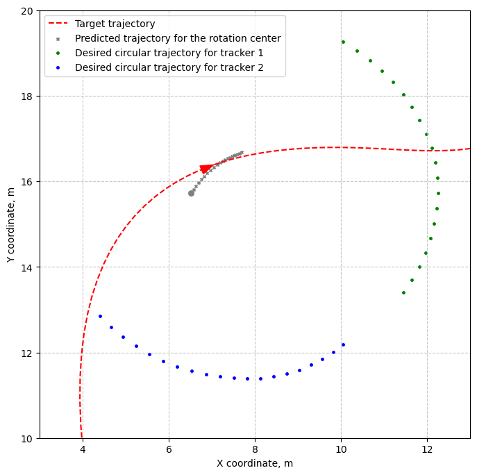

## Trackers Trajectory (Animation)

[video not shown]

## Trackers Trajectory (Static)

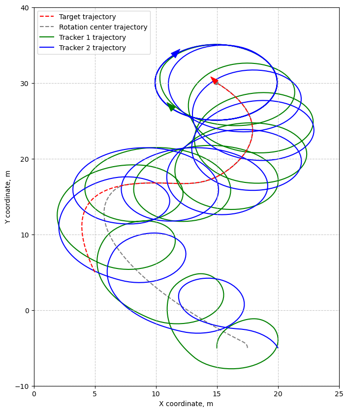

## Trackers state

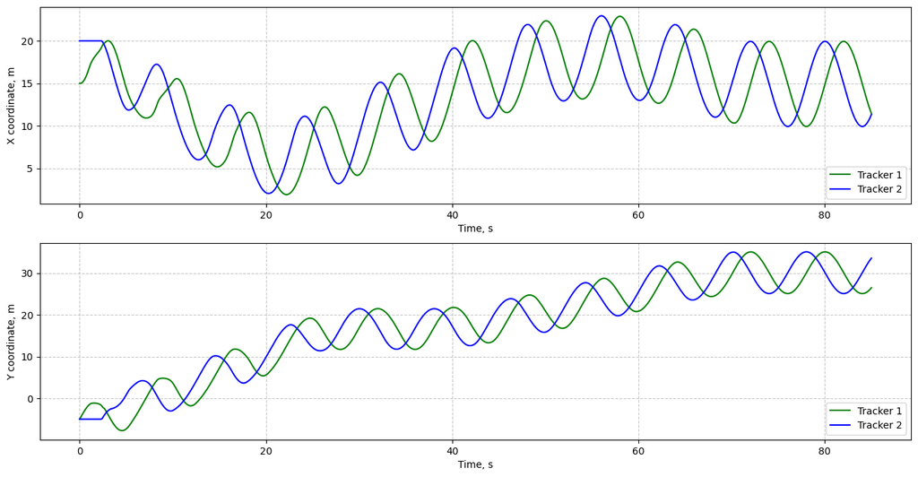

## Trackers control vector

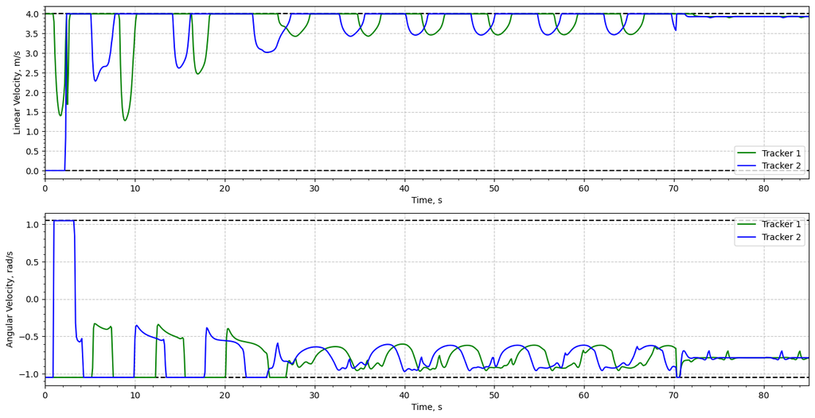

## Cumulative Solution Histogram for the Circulation Trajectory

[video not shown]

# Conclusions

- We present an optimization-based approach to the problem of single target pursuit by two trackers with simultaneous data collection for target localization using the TDoA technique is proposed.
- The underlying idea in the proposed method is the decomposition of the pursuit problem into two MPC approaches: tracking the target by an imaginary rotation point and orbiting the rotation point by the trackers.
- The efficiency of the proposed approach for the target localization task is demonstrated using the time cumulative histogram approach.
- The MPC approaches were implemented using the CasADi software package. The control loops for both MPC controllers are computed in 30ms due to the use of a multiple shot approach. The implementation can be used for real-time control of trackers (ASVs).

# Future Work

- In future studies, the **SLAP** problem will be addressed for the case when the position and velocity of the target are unknown and must be estimated in real-time.
- For this purpose, the localization technique will be formulated in an estimation-theoretical setting, which involves the computation of an appropriately defined Bayesian Fisher Information Matrix.

# Thank you for attention

**Presenter**: Anton Tolstonogov

**Title**: TDoA-based Target Pursuit: A Model Predictive Control Approach

**Open in Google Colab**: https://colab.research.google.com/github/bioniwulf/DSO-FinalProject/blob/main/Notebook.ipynb

**QR code for online access is below**

[figure not shown]